# Reproducible Research - Assignment 1

Navneet Latawa

Sunday, 16 Aug 2015

## Introduction

It is now possible to collect a large amount of data about personal movement using activity monitoring devices such as a Fitbit, Nike Fuelband, or Jawbone Up. These type of devices are part of the “quantified self” movement - a group of enthusiasts who take measurements about themselves regularly to improve their health, to find patterns in their behavior, or because they are tech geeks. But these data remain under-utilized both because the raw data are hard to obtain and there is a lack of statistical methods and software for processing and interpreting the data.

This assignment makes use of data from a personal activity monitoring device. This device collects data at 5 minute intervals through out the day. The data consists of two months of data from an anonymous individual collected during the months of October and November, 2012 and include the number of steps taken in 5 minute intervals each day.

## Data

The data for this assignment can be downloaded from the course web site:

Dataset: Activity monitoring data [52K] The variables included in this dataset are:

steps: Number of steps taking in a 5-minute interval (missing values are coded as NA)

date: The date on which the measurement was taken in YYYY-MM-DD format

interval: Identifier for the 5-minute interval in which measurement was taken

The dataset is stored in a comma-separated-value (CSV) file and there are a total of 17,568 observations in this dataset.

## Solution

### Set working Directory

Set Working directory using setwd() command

```r
setwd("D:\\Documents\\Downloads\\RR\\Week 2\\Assignment")
```

### Download Data

Download [Activity monitoring data](https://d396qusza40orc.cloudfront.net/repdata%2Fdata%2Factivity.zip) to the working directory.

### Load packages

```r
library(lattice)
library("knitr")
```

```r
library("ggplot2")
library(plyr)
```

## Loading and preprocessing the data

### Read input Data

```r
activityData<-read.csv("activity.csv")
```

#### Check number of records

```r
rows<-nrow(activityData)
```

Total number of observations are 17568

#### Remove NA data

```r
actData<-activityData[complete.cases(activityData),]
rowsWithoutNA<- nrow(actData)
missingValuesCount <- rows -  rowsWithoutNA
```

Total number of observations after removing NA data are 15264

#### Histogram of the Total number of steps taken per day

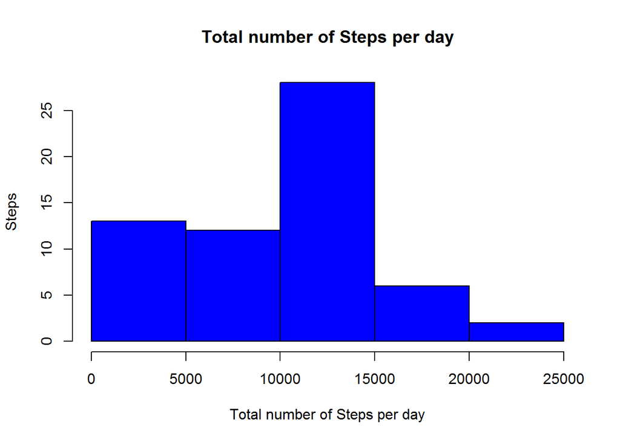

```r
dateWise<-split(actData$steps, actData$date)
sumDateWise<-sapply(dateWise,sum)

hist(sumDateWise, main ="Total number of Steps per day", xlab = "Total number of Steps per day", ylab ="Steps", col = "blue")
```

#### What is mean total number of steps taken per day?

```r
meanData<-mean(sumDateWise)

medianData<-median(sumDateWise)
```

Mean number of steps taken per day are 9354.2295082

Median number of steps taken per day are 10395

#### What is the average daily activity pattern?

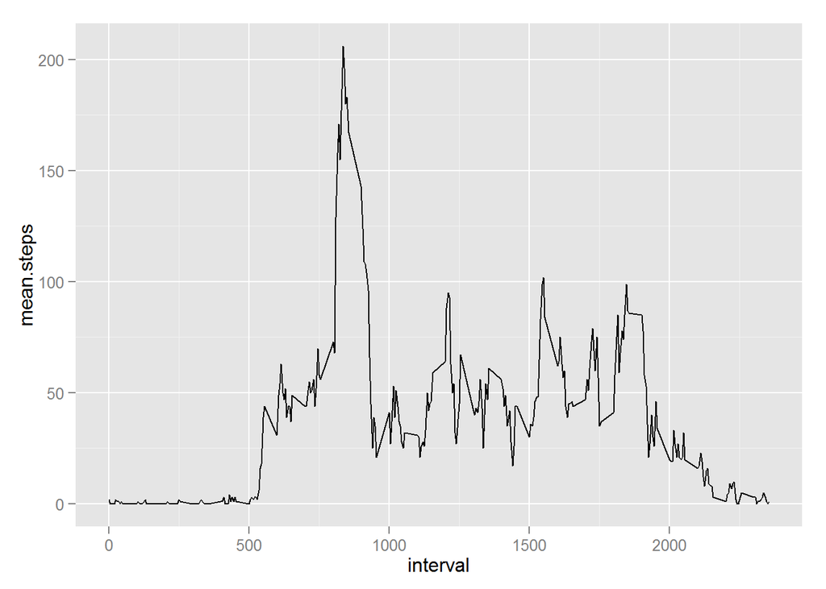

```r
meanSteps <- aggregate(actData$steps, by = list(actData$interval), mean)
medSteps <- aggregate(actData$steps, by = list(actData$interval), median)

meanSteps <- cbind(meanSteps[], medSteps$x)

#Tidy the df names and round the numbers
names(meanSteps) = c("interval","mean.steps", "median.steps")
meanSteps$mean.steps <- round(meanSteps$mean.steps)
meanSteps$median.steps <- round(meanSteps$median.steps)
maxsteps <- meanSteps$interval[meanSteps$mean.steps == max(meanSteps$mean.steps)]


ggplot(meanSteps, aes(x = interval, y = mean.steps)) + geom_line()
```

#### Inputing missing values

Missing values in the dataset are 2304

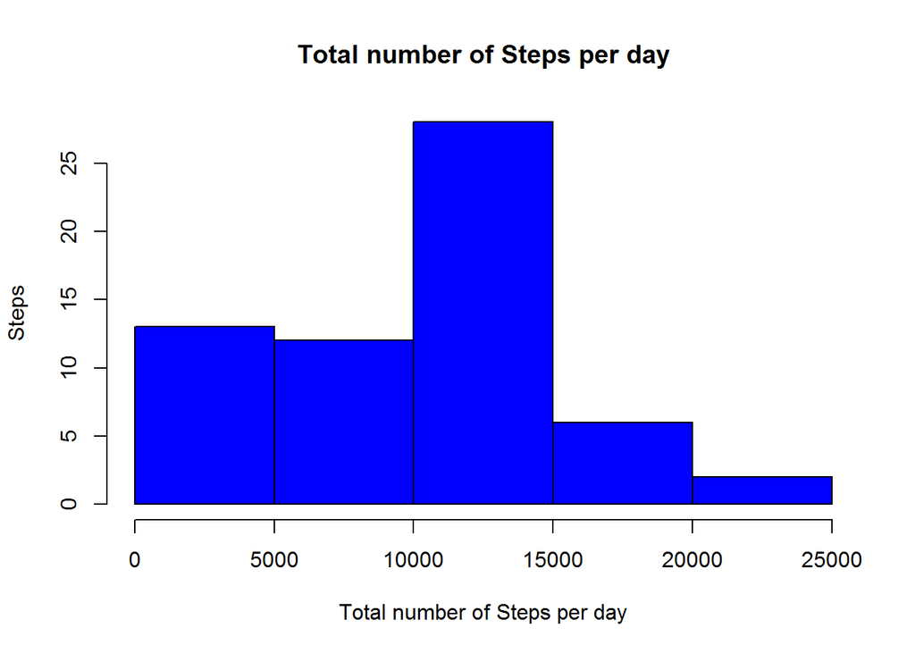

```r
medStepsIntvl <- as.data.frame(tapply(actData$steps,
                                      INDEX = actData$interval,
                                      FUN = "median", na.rm = TRUE))

colnames(medStepsIntvl) <- "medianSteps"
#Name rownames to interval as INDEX has created unterval as rownames
medStepsIntvl$interval <- rownames(medStepsIntvl)
row.names(medStepsIntvl)<-NULL
mean_median<-merge(medStepsIntvl,meanSteps, by="interval")
#merge mean and median with original data with missing
activityDataMerged<-merge(activityData,mean_median, by="interval")

for (i in (1:nrow(activityDataMerged))) {
  if (is.na(activityDataMerged$steps[i])) {
    activityDataMerged$steps[i] <- activityDataMerged$medianSteps[i]
  }
}


dateWiseNew<-split(activityDataMerged$steps, activityDataMerged$date)
sumDateWiseNew<-sapply(dateWiseNew,sum)

hist(sumDateWiseNew, main ="Total number of Steps per day", xlab = "Total number of Steps per day", ylab ="Steps", col = "blue")
```

```r
meanDataNew<-mean(sumDateWiseNew)

medianDataNew<-median(sumDateWiseNew)
```

Mean number of steps taken per day are 9503.8688525

Median number of steps taken per day are 10395

Mean has changed from 9354.2295082 to 9503.8688525 but median value(10395) has remained same even after filling NA values with median.

#### Are there differences in activity patterns between weekdays and weekends?

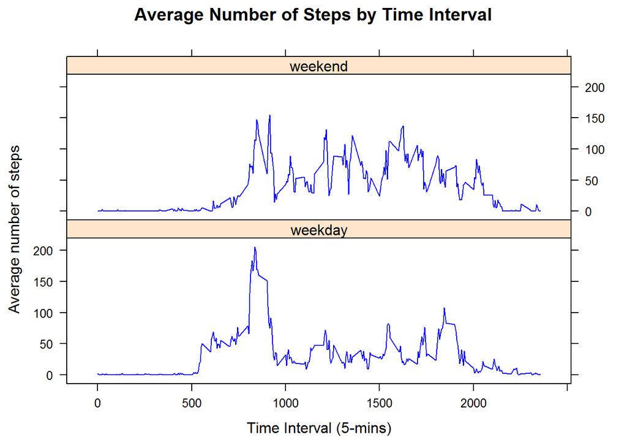

```r
activityDataMerged$weekdays <- grepl("^[Ss]", weekdays(as.Date(activityDataMerged$date)))

for (i in (1:nrow(activityDataMerged))) {
    if (activityDataMerged$weekdays[i] == TRUE) {
        activityDataMerged$week_day_factor[i] <- "weekend"
    } else {
        activityDataMerged$week_day_factor[i] <- "weekday"
    }
}

mean_stps_per_intvl_input <- aggregate(activityDataMerged$steps, by = list(activityDataMerged$interval,
    activityDataMerged$week_day_factor), FUN = "mean", na.rm = TRUE)
colnames(mean_stps_per_intvl_input) <- c("interval", "weekday", "avg_steps")

sort_order <- order(as.numeric(mean_stps_per_intvl_input$interval))
mean_stps_per_intvl <- mean_stps_per_intvl_input[sort_order, ]

mean_by_day_type <- aggregate( activityDataMerged$steps, by = list( activityDataMerged$week_day_factor),
    FUN = "mean", na.rm = TRUE)
mean_weekdays <- round(mean_by_day_type[1, 2], 2)
mean_weekends <- round(mean_by_day_type[2, 2], 2)

xyplot(data = mean_stps_per_intvl,
       avg_steps ~ as.numeric(interval) | as.factor(weekday),
           type = "l", layout = c(1, 2), col = c("blue","red"),
    main = "Average Number of Steps by Time Interval",
    xlab = "Time Interval (5-mins)", ylab = "Average number of steps")
```

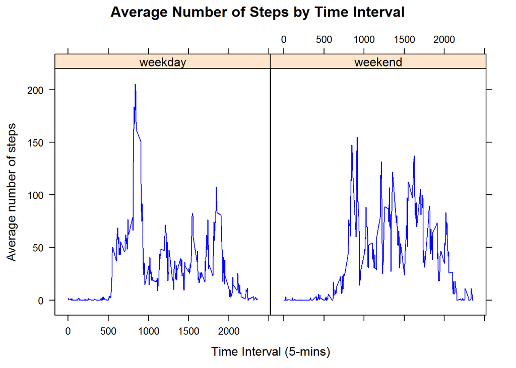

```r
xyplot(data = mean_stps_per_intvl,
       avg_steps ~ as.numeric(interval) | as.factor(weekday),
           type = "l", layout = c(2, 1), col = c("blue","red"),
    main = "Average Number of Steps by Time Interval",
    xlab = "Time Interval (5-mins)", ylab = "Average number of steps")
```